```python
import pandas as pd
```

# Problem 3

```python
df= pd.read_csv('Data/ChicagoSalaries/ChicagoSalaries.csv')
df.head(5)
```

|  | Name | Job Titles | Department | Full or Part-Time | Salary or Hourly | Typical Hours | Annual Salary | Hourly Rate |
| --- | --- | --- | --- | --- | --- | --- | --- | --- |
| 0 | AARON, JEFFERY M | SERGEANT | POLICE | F | Salary | NaN | $101442.00 | NaN |
| 1 | AARON, KARINA | POLICE OFFICER (ASSIGNED AS DETECTIVE) | POLICE | F | Salary | NaN | $94122.00 | NaN |
| 2 | AARON, KIMBERLEI R | CHIEF CONTRACT EXPEDITER | GENERAL SERVICES | F | Salary | NaN | $101592.00 | NaN |
| 3 | ABAD JR, VICENTE M | CIVIL ENGINEER IV | WATER MGMNT | F | Salary | NaN | $110064.00 | NaN |
| 4 | ABARCA, EMMANUEL | CONCRETE LABORER | TRANSPORTN | F | Hourly | 40.0 | NaN | $36.18 |

```python
# (a) (2 pts) How many employees does the City of Chicago have?
n = df['Name'].count()
n
```

```
32812
```

```python
# (b) (2 pts) What is the total amount that the City of Chicago spends on employee salaries? Hint: The .str.strip() method may be useful.
df['Annual Salary'] = df['Annual Salary'].str.strip('$')
df['Annual Salary'] = df['Annual Salary'].astype(float)
total_s = df['Annual Salary'].sum()
total_s
```

```
2178570595.68
```

```python
#(c) (2 pts) What is the average salary of a City of Chicago employee?
s.mean()
```

```
87313.95918720697
```

```python
# avg salary
total_s/(n - s.isna().sum()) # there is missing data
```

```
87313.95918720691
```

```python
# (d) (2 pts) What is the median salary of a City of Chicago employee?
s.dropna()
s.median()
```

```
90024.0
```

```python
# (e) (2 pts) How many different city departments does the City of Chicago have?
gp = df.groupby('Department')
gp.ngroups
```

```
36
```

```python
# (f) (2 pts) Which city department has the most employees?
gp.count().Name.sort_values(ascending=False)

#POLICE
```

```
Department
POLICE                   13061
FIRE                      4837
OEMC                      2121
STREETS & SAN             2035
WATER MGMNT               1905
AVIATION                  1414
TRANSPORTN                1242
PUBLIC LIBRARY             984
GENERAL SERVICES           964
FAMILY & SUPPORT           626
FINANCE                    564
HEALTH                     505
CITY COUNCIL               448
LAW                        392
BUILDINGS                  277
COMMUNITY DEVELOPMENT      204
BUSINESS AFFAIRS           161
COPA                       115
BOARD OF ELECTION          103
DoIT                        98
PROCUREMENT                 97
CITY CLERK                  89
MAYOR'S OFFICE              89
INSPECTOR GEN               87
ANIMAL CONTRL               80
HUMAN RESOURCES             70
CULTURAL AFFAIRS            67
BUDGET & MGMT               46
ADMIN HEARNG                39
DISABILITIES                29
TREASURER                   22
HUMAN RELATIONS             17
IPRA                        13
BOARD OF ETHICS              8
POLICE BOARD                 2
LICENSE APPL COMM            1
Name: Name, dtype: int64
```

```python
# (g) (2 pts) Which city department has the highest median salary?
gp['Annual Salary'].median().sort_values(ascending=False)

#IPRA
```

```
Department
IPRA                     101592.00
BUILDINGS                100256.04
DoIT                      97056.00
FIRE                      93666.00
WATER MGMNT               92556.00
TRANSPORTN                92388.00
HUMAN RELATIONS           92388.00
BUDGET & MGMT             91608.00
COMMUNITY DEVELOPMENT     91128.00
TREASURER                 90858.00
POLICE                    90024.00
BOARD OF ETHICS           89076.00
CULTURAL AFFAIRS          88758.00
POLICE BOARD              86136.00
DISABILITIES              84516.00
HEALTH                    84420.00
STREETS & SAN             84384.00
GENERAL SERVICES          83484.00
BUSINESS AFFAIRS          80568.00
LICENSE APPL COMM         80568.00
MAYOR'S OFFICE            80004.00
LAW                       79968.00
FAMILY & SUPPORT          76932.00
PROCUREMENT               76716.00
INSPECTOR GEN             76536.00
HUMAN RESOURCES           75792.00
AVIATION                  73992.00
COPA                      73440.00
OEMC                      70644.00
FINANCE                   70092.00
PUBLIC LIBRARY            70092.00
ADMIN HEARNG              70092.00
CITY CLERK                66948.00
ANIMAL CONTRL             64392.00
CITY COUNCIL              57036.00
BOARD OF ELECTION         46860.00
Name: Annual Salary, dtype: float64
```

```python
#(h) (2 pts) Which city position has the highest median salary?
gp2 = df.groupby('Job Titles')
gp2['Annual Salary'].median().sort_values(ascending=False)

#COMMISSIONER OF AVIATION
```

```
Job Titles
COMMISSIONER OF AVIATION           300000.0
SUPERINTENDENT OF POLICE           260004.0
MAYOR                              216210.0
FIRE COMMISSIONER                  202728.0
FIRST DEPUTY FIRE COMMISSIONER     197736.0
                                     ...
WATCHMAN                                NaN
WATER METER MACHINIST                   NaN
WATER METER MACHINIST - TRAINEE         NaN
WEIGHMASTER                             NaN
WINDOW WASHER                           NaN
Name: Annual Salary, Length: 1121, dtype: float64
```

```python
#(i) (2 pts) Which city position has the lowest median salary?
gp2['Annual Salary'].median().sort_values()

#CLERK CITY COUNCIL
```

```
Job Titles
CLERK CITY COUNCIL                    26730.0
CLERK - BD OF ELECTIONS               29328.0
ELECTION EQUIPMENT & SUPPLY SPEC I    30060.0
POLLING PLACE INVESTIGATOR I          31200.0
ALDERMANIC AIDE                       33219.0
                                       ...
WATCHMAN                                  NaN
WATER METER MACHINIST                     NaN
WATER METER MACHINIST - TRAINEE           NaN
WEIGHMASTER                               NaN
WINDOW WASHER                             NaN
Name: Annual Salary, Length: 1121, dtype: float64
```

```python
#(j) (2 pts) Which city position has the most employees?
gp2.count().Name.sort_values(ascending=False)

#POLICE OFFICER
```

```
Job Titles
POLICE OFFICER                            9216
FIREFIGHTER-EMT                           1491
SERGEANT                                  1163
POLICE OFFICER (ASSIGNED AS DETECTIVE)    1016
MOTOR TRUCK DRIVER                         707
                                          ...
DIR OF HUMAN RESOURCES                       1
DIR OF INTERGOVERNMENTAL AFFAIRS             1
DIR OF LABOR RELATIONS                       1
DIR OF LIBRARY - PROGRAMS AND EXHIBITS       1
1ST DEPUTY INSPECTOR GENERAL                 1
Name: Name, Length: 1121, dtype: int64
```

# Problem 4

```python
df= pd.read_csv('Data/RealEstate/RealEstate.csv')
#df.Location = df.Location.apply(lambda x: x.strip()) # strips extra white spaces will cause subtle errors
df.head(5)
```

|  | MLS | Location | Price | Bedrooms | Bathrooms | Size | Price/SQ.Ft | Status |
| --- | --- | --- | --- | --- | --- | --- | --- | --- |
| 0 | 132842 | Arroyo Grande | 795000.0 | 3 | 3 | 2371 | 335.30 | Short Sale |
| 1 | 134364 | Paso Robles | 399000.0 | 4 | 3 | 2818 | 141.59 | Short Sale |
| 2 | 135141 | Paso Robles | 545000.0 | 4 | 3 | 3032 | 179.75 | Short Sale |
| 3 | 135712 | Morro Bay | 909000.0 | 4 | 4 | 3540 | 256.78 | Short Sale |
| 4 | 136282 | Santa Maria-Orcutt | 109900.0 | 3 | 1 | 1249 | 87.99 | Short Sale |

### (a) (5 pts) What are the top three locations with the most expensive median price per square foot? What are the bottom three locations with the least expensive median prices per square foot?

```python
#most expensive
gp = df.groupby('Location')
gp['Price/SQ.Ft'].median().sort_values(ascending=False).head(3)
```

```
Location
 Oceano        1144.64
Avila Beach     636.96
 Bradley        606.06
Name: Price/SQ.Ft, dtype: float64
```

```python
#least expensive
gp['Price/SQ.Ft'].median().sort_values().head(3)
```

```
Location
New Cuyama     34.05
Bakersfield    69.69
King City      74.68
Name: Price/SQ.Ft, dtype: float64
```

### (b) (5 pts) Complete a cross-tabulation of the number of bedrooms and bathrooms a house has. What type of house is the most common house in the data set? Is it more common for a house to have more bedrooms than bathrooms or more bathrooms than bedrooms? Explain what the data suggests.

```python
pd.crosstab(df['Bedrooms'],df['Bathrooms'])
```

| Bathrooms Bedrooms | 1 | 2 | 3 | 4 | 5 | 6 | 7 | 11 |
| --- | --- | --- | --- | --- | --- | --- | --- | --- |
| 0 | 2 | 0 | 0 | 0 | 0 | 0 | 0 | 0 |
| 1 | 10 | 1 | 0 | 0 | 0 | 0 | 0 | 0 |
| 2 | 33 | 78 | 12 | 0 | 0 | 0 | 0 | 0 |
| 3 | 20 | 286 | 119 | 5 | 1 | 0 | 0 | 0 |
| 4 | 0 | 76 | 76 | 19 | 6 | 0 | 0 | 0 |
| 5 | 0 | 3 | 16 | 9 | 0 | 2 | 1 | 0 |
| 6 | 0 | 0 | 3 | 0 | 0 | 0 | 1 | 0 |
| 7 | 0 | 0 | 0 | 0 | 1 | 0 | 0 | 0 |
| 10 | 0 | 0 | 0 | 0 | 0 | 0 | 0 | 1 |

houses with 2 bathrooms and 3 bedrooms are the most common house in the data set. It is more common for a house to have more bedrooms than bathrooms.

### (c) (5 pts) How strong is the correlation between the size of a house and the price of a house? Compute the correlation coefficient.

```python
df['Size'].corr(df['Price'])
```

```
0.664723613865808
```

### (d) (5 pts) Create the table below filled with the appropriate numbers in your Jupyter notebook. Use the median to aggregate each group.

```python
gp3 = df.groupby('Status')
gp3['Price/SQ.Ft','Price','Size'].median()
```

| Status | Price/SQ.Ft | Price | Size |
| --- | --- | --- | --- |
| Foreclosure | 186.780 | 278950.0 | 1500 |
| Regular | 282.690 | 509000.0 | 1832 |
| Short Sale | 175.405 | 277000.0 | 1526 |

### (e) (5 pts) Submit box plots comparing the price per square foot of houses in Atascadero to houses in Paso Robles. What conclusions can be drawn from the box plots?

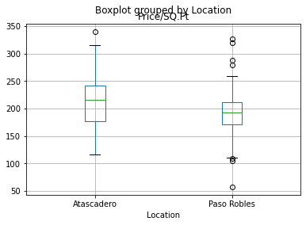

```python
pd1 = pd.concat([df.groupby('Location').get_group('Paso Robles'),df.groupby('Location').get_group('Atascadero')])
pd1.boxplot(column='Price/SQ.Ft', by='Location')
#df.groupby('Location').get_group('Atascadero').boxplot(column='Price/SQ.Ft')
#plt.show()
```

The prices per square foot of houses in Atascadero have bigger variability and general more expensive than houses in Paso Robles.

### Cleaning data for inconsistent formatting

```python
(df.Location == 'Atascadero').sum()
```

```
58
```

```python
(df.Location.str.contains('Atascadero')).sum()
```

```
68
```

```python
(df.Location.str.strip() == 'Atascadero').sum()
```

```
68
```

The problem seems to be extra white spaces in the names. A pipeline for preprocessing this data could clean the data by having a .str.strip() step to remove any leading or trailing white spaces.

```python
(df.Location=='Paso Robles').sum()
```

```
85
```

```python
(df.Location.str.contains('Paso Robles')).sum()
```

```
100
```

```python
#Ignore white spaces in the names.

Atascadero = df[df.Location.str.contains('Atascadero')]['Price/SQ.Ft']
Paso = df[df.Location.str.contains('Paso Robles')]['Price/SQ.Ft']
```

```python
Atascadero.shape
```

```
(68,)
```

```python
Paso.shape
```

```
(100,)
```

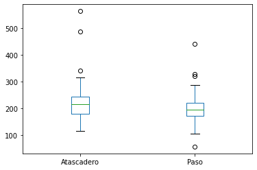

```python
Atascadero_Paso = pd.concat([Atascadero,Paso],axis=1,keys=['Atascadero','Paso'])
Atascadero_Paso.plot.box()
```